# Bioestadística

## Distribución Normal

### Definición

La distribución **Normal** (o gaussiana) es la distribución continua más importante en estadística. Una variable $X$ sigue una distribución Normal con media $\mu$ y varianza $\sigma^2$:

$$X \sim N(\mu, \sigma^2)$$

### Función de densidad

$$\boxed{f(x) = \frac{1}{\sigma\sqrt{2\pi}}\; e^{-\frac{(x-\mu)^2}{2\sigma^2}}, \quad x \in \mathbb{R}}$$

## Propiedades de la Distribución Normal

- **Simétrica** respecto a $\mu$
- **Unimodal** con moda = mediana = $\mu$
- La curva es asintótica al eje X
- $E[X] = \mu$, $Var(X) = \sigma^2$
- El parámetro $\sigma$ controla la **dispersión**

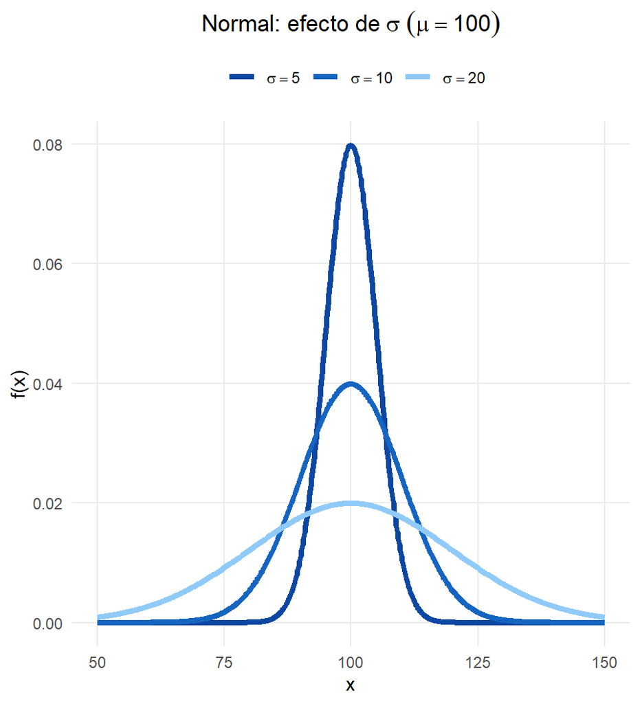

## Regla 68 — 95 — 99.7

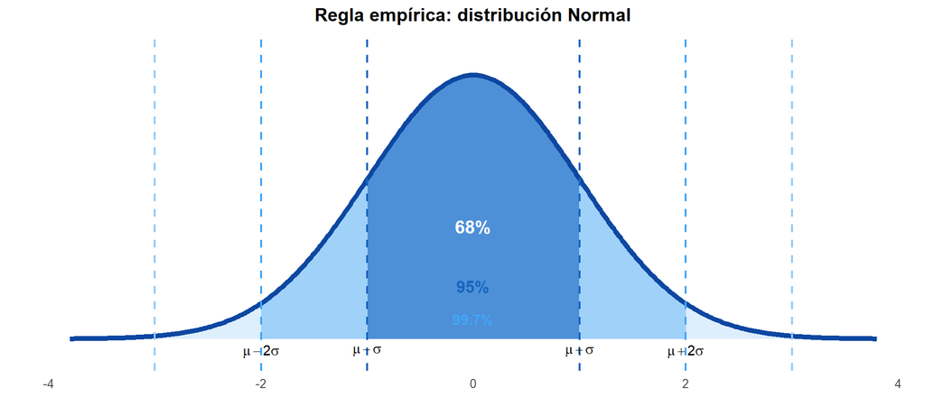

$$P(\mu - \sigma \leq X \leq \mu + \sigma) \approx 0.68 \qquad P(\mu - 2\sigma \leq X \leq \mu + 2\sigma) \approx 0.95$$

## Ejemplo: Concentración de un principio activo

La **concentración de un principio activo** (mg) en un lote de tabletas sigue una distribución aproximadamente normal:

$$\text{Concentración} \sim N(120,\; 15^2) \text{ mg}$$

**¿Qué proporción de lotes tiene una concentración entre 105 y 135 mg?**

$$P(105 \leq C \leq 135) = P(120 - 15 \leq C \leq 120 + 15) \approx 0.68$$

**¿Cuál es la probabilidad de que un lote exceda el límite superior de especificación (C > 140 mg)?**

$$P(C > 140) = 1 - P(C \leq 140)$$

*Usaremos `pnorm` en R para calcularlo.*

## Código R: Distribución Normal

```r
# Concentración ~ N(120, 15^2) mg

# P(Concentración < 130): lote por debajo de 130 mg
pnorm(q = 130, mean = 120, sd = 15)
```

```
[1] 0.7475075
```

```r
# P(Concentración > 140): lote fuera de especificación (> 140 mg)
1 - pnorm(q = 140, mean = 120, sd = 15)
```

```
[1] 0.09121122
```

```r
# P(105 < Concentración < 135): rango dentro de especificación (± 1 desv. estándar)
pnorm(135, 120, 15) - pnorm(105, 120, 15)
```

```
[1] 0.6826895
```

```r
# Percentil 95 de la concentración (valor de corte)
qnorm(p = 0.95, mean = 120, sd = 15)
```

```
[1] 144.6728
```

## Distribución Normal Estándar

### Estandarización

Si $X \sim N(\mu, \sigma^2)$, la variable **estandarizada** sigue una Normal Estándar:

$$\boxed{Z = \frac{X - \mu}{\sigma} \sim N(0, 1)}$$

> La estandarización permite comparar valores de **diferentes escalas** y usar una única tabla (o función R).

### Propiedades de $Z \sim N(0,1)$

- $E[Z] = 0$, $Var(Z) = 1$
- $f(z) = \dfrac{1}{\sqrt{2\pi}} e^{-z^2/2}$
- Simétrica: $P(Z \leq -z) = P(Z \geq z) = 1 - \Phi(z)$

## Cuantiles y Percentiles

La función $\Phi(z) = P(Z \leq z)$ se implementa con `pnorm` en R.

### Valores críticos más usados

| Nivel | $z_{\alpha/2}$ |
| --- | --- |
| 90% | $z_{0.05} = 1.645$ |
| 95% | $z_{0.025} = 1.960$ |
| 99% | $z_{0.005} = 2.576$ |

### En R

```r
# Percentil 97.5
qnorm(0.975)
```

```
[1] 1.959964
```

```r
# Percentil 99.5
qnorm(0.995)
```

```
[1] 2.575829
```

```r
# P(Z < 1.96)
pnorm(1.96)
```

```
[1] 0.9750021
```

## Código R: Normal Estándar y Estandarización

```r
# P(-1.96 < Z < 1.96)
pnorm(1.96) - pnorm(-1.96)
```

```
[1] 0.9500042
```

```r
# Estandarizar: Concentración = 145 mg (mu=120, sigma=15)
z <- (145 - 120) / 15
cat("Z =", round(z, 3))
```

```
Z = 1.667
```

```r
cat("\nP(Concentración > 145) = P(Z >", round(z, 3), ") =",
    round(1 - pnorm(z), 4))
```

```
P(Concentración > 145) = P(Z > 1.667 ) = 0.0478
```

```r
# Rango de referencia: intervalo que contiene el 95% central de los lotes
cat("\nIntervalo central del 95%: [",
    round(qnorm(0.025, 120, 15), 1), ",",
    round(qnorm(0.975, 120, 15), 1), "] mg")
```

```
Intervalo central del 95%: [ 90.6 , 149.4 ] mg
```

## Ejemplo: Concentración de plomo en agua potable

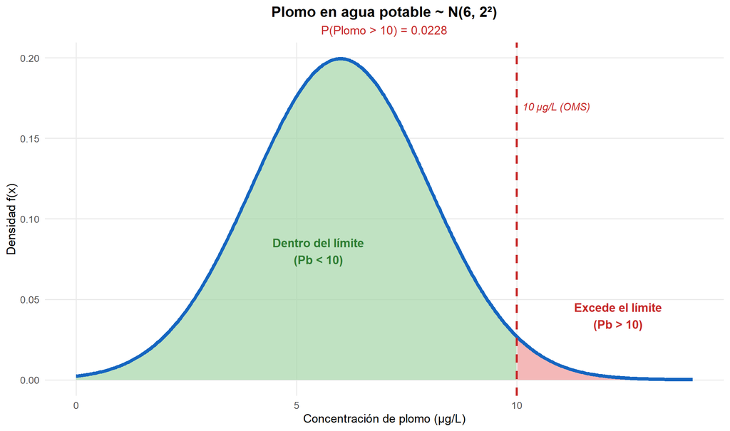

### Código R del ejemplo de plomo en agua

```r
# Concentración de plomo en agua potable ~ N(6, 2^2) µg/L
# Límite de la OMS: 10 µg/L

# P(Plomo >= 10): probabilidad de exceder el límite regulatorio
1 - pnorm(q = 10, mean = 6, sd = 2)
```

```
[1] 0.02275013
```

```r
# Valor de corte para alerta temprana (percentil 80)
qnorm(p = 0.80, mean = 6, sd = 2)
```

```
[1] 7.683242
```

```r
# Simular 500 muestras y calcular la proporción que supera 10
set.seed(2024)
plomo <- rnorm(n = 500, mean = 6, sd = 2)
mean(plomo >= 10)
```

```
[1] 0.02
```

## Tu turno: Distribución Normal

**Tu turno**

**Ejercicio 1.** La altura $X$ (cm) de una especie de planta sigue $X \sim N(50, 8^2)$.

Calcula $P(X > 60)$ y $P(40 < X < 55)$.

**Ejercicio 2.** El pH $X$ de muestras de suelo en una región sigue $X \sim N(6.5, 0.4^2)$.

Calcula $P(X < 6)$ y el percentil 90 de $X$.

## Solución

**Ejercicio 1:**

$$P(X>60) = 1-\Phi\left(\frac{60-50}{8}\right) = 1-\Phi(1.25) \approx \mathbf{0.106}$$

$$P(40<X<55) = \Phi(0.625) - \Phi(-1.25) \approx \mathbf{0.628}$$

**Ejercicio 2:**

$$P(X<6) = \Phi\left(\frac{6-6.5}{0.4}\right) = \Phi(-1.25) \approx \mathbf{0.106}$$

$$\text{Percentil 90} = 6.5 + 1.2816 \times 0.4 \approx \mathbf{7.01}$$

```r
1 - pnorm(60, 50, 8); pnorm(55, 50, 8) - pnorm(40, 50, 8)
```

```
[1] 0.1056498
```

```
[1] 0.6283647
```

```r
pnorm(6, 6.5, 0.4); qnorm(0.90, 6.5, 0.4)
```

```
[1] 0.1056498
```

```
[1] 7.012621
```

# GRACIAS!

# Citación y derechos de autor

Este material ha sido creado por [Giovany Babativa-Márquez](https://github.com/jgbabativam) y es de libre distribución bajo la licencia [Creative Commons Attribution-ShareAlike 4.0](https://creativecommons.org/licenses/by-sa/4.0/).

Cualquier copia parcial o total de este material, debe citar la fuente como:

> Babativa-Márquez, J.G. *Diapositivas del curso de Bioestadística*. URL: https://jgbabativam.github.io/EstadFundSalud/